# *Acropora cervicornis* Growth by Genotype

# Connecting Across Datasets

When we filter traits that have at least 3 growth traits, we can begin to identify patterns. Ordination can help visualize these patterns.

| genotype | 6-month productivity | annual linear growth | annual growth per branch | origin nursery | daily calcification | normalized daily calcification | annual colony volumetric growth | bulk density | SA normalized daily calcification | dark calcification | light calcification | 6-month colony volumetric growth | 6-month interstitial space growth | annual interstitial space growth |
| --- | --- | --- | --- | --- | --- | --- | --- | --- | --- | --- | --- | --- | --- | --- |
| 41 | 1.3503317 | 2.3479532 | 0.000000 | Mote | 11.911631 | 1.362838 | 4.092277 | 1.1950000 | 0.7900653 | 0.3319500 | 0.4619500 | 2.318153 | 6.354449 | 16.71876 |
| 7 | 0.9895301 | 1.8661312 | 0.000000 | Mote | 16.489037 | 1.529857 | 7.251908 | 1.1866667 | 0.7608288 | 0.3150526 | 0.4947368 | 1.882112 | 6.949839 | 32.13682 |
| 31 | 1.8699305 | 2.3575844 | 0.000000 | Mote | 11.499020 | 1.978562 | 2.727173 | 1.0500000 | 1.0894636 | 0.4551000 | 0.6157000 | 1.541100 | 6.426992 | 16.41852 |
| 44 | 1.1507973 | 2.5548639 | 0.000000 | Mote | 10.143850 | 1.289407 | 6.347457 | 1.1650000 | 0.7722514 | 0.3521250 | 0.5650000 | 1.314861 | 4.377032 | 17.44152 |
| 1 | 1.5008854 | 2.2237042 | 0.000000 | Mote | 14.115726 | 1.256606 | 4.630126 | 1.1733333 | 1.1360423 | 0.2805714 | 0.4307500 | 1.308189 | 3.987677 | 17.73707 |
| 62 | 1.3524030 | 2.4354034 | 0.000000 | Mote | 8.419118 | 1.549000 | 6.670650 |  | 0.7553410 | 0.2301000 | 0.3915000 | 1.730288 | 7.542649 | 30.94065 |
| 50 | 1.5540484 | 2.8022731 | 0.000000 | Mote | 8.241830 | 1.805592 | 6.048552 |  | 0.9774938 | 0.3820000 | 0.4498947 | 1.559047 | 6.700509 | 30.45730 |
| 3 | 1.7054435 | 2.2685618 | 0.000000 | Mote | 7.905882 | 1.556453 | 5.130256 |  | 0.8253083 | 0.3269000 | 0.5273000 | 1.513227 | 5.786850 | 19.12090 |
| 13 | 1.2984237 | 1.7060498 | 0.000000 | Mote | 4.874265 | 1.013570 | 2.942626 |  | 0.6459253 | 0.3188500 | 0.4787500 | 1.128490 | 5.893239 | 16.48818 |
| 36 | 0.9554472 | 1.8228465 | 0.000000 | CRF |  |  | 5.821959 |  |  |  |  | 1.707363 | 7.965897 | 23.95219 |
| U41 | 4.1702551 | 10.2694437 | 124.888175 | CRF | 159.829252 | 65.666098 | 5.301325 |  |  |  |  |  |  |  |
| K3 | 3.9732054 | 8.0927963 | 84.655813 | CRF | 189.469996 | 84.942898 | 2.391167 |  |  |  |  |  |  |  |
| U77 | 3.1228080 | 6.3725357 | 72.718509 | CRF | 150.692167 | 54.899549 | 6.980605 |  |  |  |  |  |  |  |
| K2 | 3.1104864 | 8.6084023 | 103.375316 | CRF | 199.954903 | 84.647075 | 2.543432 |  |  |  |  |  |  |  |
| U44 | 3.0385502 | 6.4694913 | 81.820051 | CRF | 123.635032 | 47.157034 | 4.261328 |  |  |  |  |  |  |  |
| 34 | 2.9539057 |  |  | Mote | 8.235294 | 1.403507 |  |  | 0.7276813 | 0.2040000 | 0.3465714 |  |  |  |
| U73 | 3.1818130 | 7.8413159 | 109.406170 | CRF | 137.153187 | 46.886383 |  |  |  |  |  |  |  |  |
| U47 | 3.0832195 | 7.4804617 | 100.304627 | CRF | 120.053957 | 52.366660 |  |  |  |  |  |  |  |  |
| U78 | 2.8834225 | 7.5315675 | 94.925021 | CRF | 146.814641 | 47.163187 |  |  |  |  |  |  |  |  |
| K1 | 2.5770306 | 6.7185054 | 80.694087 | CRF | 90.842151 | 34.868624 |  |  |  |  |  |  |  |  |
| K25 | 2.5271672 | 3.8358136 | 52.310411 | CRF | 72.799167 | 23.202719 |  |  |  |  |  |  |  |  |
| 5 | 2.0504027 | 3.7958216 | 0.000000 | Mote | 63.400000 |  |  | 1.0500000 |  |  |  |  |  |  |
| 56 | 1.7973232 | 2.0588750 | 0.000000 | Mote | 22.900000 |  |  | 1.2600000 |  |  |  |  |  |  |
| 54 | 1.4063779 | 2.1458059 | 0.000000 | Mote | 34.100000 |  |  | 1.3300000 |  |  |  |  |  |  |
| 63 |  |  |  | Mote | 8.263932 | 1.759538 |  |  | 1.0205114 | 0.1763889 | 0.4517368 |  |  |  |
| 47 |  |  |  | Mote | 6.235294 | 1.277770 |  |  | 0.8094416 | 0.4312000 | 0.5434000 |  |  |  |
| MK-9 | 1.5990689 | 4.0096149 | 32.942232 | Lirman/UM |  |  |  |  |  |  |  | 1.804596 |  |  |
| 20 | 2.1426730 |  |  | Mote | 10.308882 | 1.129148 |  |  | 1.3112491 |  |  |  |  |  |
| Struggle Bus | 1.6632008 | 4.5957279 | 24.445159 | Lirman/UM |  |  |  | 0.7773404 |  |  |  |  |  |  |
| Grounding | 1.2844528 | 2.2966138 | 14.115816 | Lirman/UM |  |  |  | 0.6307802 |  |  |  |  |  |  |
| Steph’s | 1.2706059 | 4.8065597 | 32.174855 | Lirman/UM |  |  |  | 0.6541826 |  |  |  |  |  |  |
| Cooper’s | 1.1046142 | 2.0845430 | 17.383218 | Lirman/UM |  |  |  | 0.7180439 |  |  |  |  |  |  |
| B | 3.6231817 | 9.4177994 | 0.000000 | Lirman DR |  |  |  |  |  |  |  |  |  |  |
| A | 2.4574613 | 2.6937517 | 0.000000 | Lirman DR |  |  |  |  |  |  |  |  |  |  |
| Acerv 1 (A-AC) | 2.0058472 | 3.9334315 | 38.165970 | Lirman/UM |  |  |  |  |  |  |  |  |  |  |
| THIN | 1.9860655 | 3.0876321 | 0.000000 | Lirman DR |  |  |  |  |  |  |  |  |  |  |
| ELK | 1.7608777 | 2.5716660 | 20.318237 | Lirman/UM |  |  |  |  |  |  |  |  |  |  |
| Acerv 5 (E-AC) | 1.7567727 | 3.2576649 | 22.035185 | Lirman/UM |  |  |  |  |  |  |  |  |  |  |
| Site 406 | 1.7328099 | 3.9592580 | 23.935935 | Lirman/UM |  |  |  |  |  |  |  |  |  |  |
| Acerv 3 (C-AC) | 1.7301334 | 3.9601944 | 36.221583 | Lirman/UM |  |  |  |  |  |  |  |  |  |  |
| Acerv 2 (B-AC) | 1.6168786 | 2.6230655 | 15.831875 | Lirman/UM |  |  |  |  |  |  |  |  |  |  |
| TT (Thicket 3) | 1.4650503 | 1.6191751 | 9.254553 | Lirman/UM |  |  |  |  |  |  |  |  |  |  |
| Acerv 4 (D-AC) | 1.4278270 | 3.8074216 | 28.828241 | Lirman/UM |  |  |  |  |  |  |  |  |  |  |
| Dom’s Reef | 1.3280824 | 4.7503108 | 33.400416 | Lirman/UM |  |  |  |  |  |  |  |  |  |  |
| 11 | 1.3228360 | 1.9267307 | 26.573291 | Mote |  |  |  |  |  |  |  |  |  |  |
| THICK | 1.2712625 | 1.4288854 | 0.000000 | Lirman DR |  |  |  |  |  |  |  |  |  |  |
| 4 | 1.1883002 | 1.8726405 | 0.000000 | Mote |  |  |  |  |  |  |  |  |  |  |
| Trav’s Reef | 1.1784577 | 4.6996842 | 29.127814 | Lirman/UM |  |  |  |  |  |  |  |  |  |  |
| M1 | 1.1523438 |  |  | CRF | 10.377391 | 0.582124 |  |  |  |  |  |  |  |  |
| Almost Done | 1.1414480 | 2.6411667 | 12.876389 | Lirman/UM |  |  |  |  |  |  |  |  |  |  |
| Britt’s Reef | 0.9564067 | 5.2356176 | 26.888333 | Lirman/UM |  |  |  |  |  |  |  |  |  |  |
| Trans 2 | 0.8109957 | 3.6542545 | 20.541389 | Lirman/UM |  |  |  |  |  |  |  |  |  |  |
| M13 | 0.8077836 | 0.4636407 | 3.129323 | CRF |  |  |  |  |  |  |  |  |  |  |
| Ford’s Reef | 0.7803511 | 4.6078421 | 23.806674 | Lirman/UM |  |  |  |  |  |  |  |  |  |  |
| Fowey | 0.7580873 | 2.1622531 | 13.197454 | Lirman/UM |  |  |  |  |  |  |  |  |  |  |
| Big Bertha | 0.7354546 | 2.9103101 | 21.253971 | Lirman/UM |  |  |  |  |  |  |  |  |  |  |
| B/B | 0.5780776 | 1.4668133 | 15.236497 | Lirman DR |  |  |  |  |  |  |  |  |  |  |
| Trans 1 | 0.5589653 | 2.4042449 | 15.411111 | Lirman/UM |  |  |  |  |  |  |  |  |  |  |
| Alina-A | 0.5303896 | 3.8780327 | 26.607301 | Lirman/UM |  |  |  |  |  |  |  |  |  |  |
| Alina-B | 0.5278130 | 4.0599385 | 24.602765 | Lirman/UM |  |  |  |  |  |  |  |  |  |  |
| W/B | 0.2814340 | 1.7523078 | 28.183511 | Lirman DR |  |  |  |  |  |  |  |  |  |  |
| W/G | 0.2547012 | 3.5388889 | 39.034722 | Lirman DR |  |  |  |  |  |  |  |  |  |  |
| W/Y | 0.2174337 | 1.1660472 | 17.912037 | Lirman DR |  |  |  |  |  |  |  |  |  |  |
| 38 |  | 3.6601437 |  | Mote | 43.800000 |  |  | 1.2200000 |  |  |  |  |  |  |
| 43 |  | 2.5898503 |  | Mote | 29.966667 |  |  | 1.1533333 |  |  |  |  |  |  |
| DR1 | 2.0054945 | 2.7096774 | 21.193548 |  |  |  |  |  |  |  |  |  |  |  |
| DT16 | 1.9531626 | 4.3253910 | 19.084005 |  |  |  |  |  |  |  |  |  |  |  |
| DT11 | 1.9019361 | 1.9392532 | 18.200941 |  |  |  |  |  |  |  |  |  |  |  |
| M12 | 1.6797593 | 1.0066108 | 7.822520 |  |  |  |  |  |  |  |  |  |  |  |
| Acer-35 | 1.5020576 | 2.0330944 | 18.348118 |  |  |  |  |  |  |  |  |  |  |  |
| DT15 | 1.0770248 | 2.5591398 | 26.688172 |  |  |  |  |  |  |  |  |  |  |  |
| DT17 | 1.0533911 | 2.5351906 | 13.981855 |  |  |  |  |  |  |  |  |  |  |  |
| DT6 | 0.9426178 | 0.9086022 | 7.653226 |  |  |  |  |  |  |  |  |  |  |  |
| DT18 | 0.7476884 | 0.9572151 | 9.591062 |  |  |  |  |  |  |  |  |  |  |  |
| DT2 | 0.7242063 | 2.6541667 | 21.291667 |  |  |  |  |  |  |  |  |  |  |  |
| Navassa | 0.7198172 | 1.0674487 | 5.887097 |  |  |  |  |  |  |  |  |  |  |  |
| Acer-063 | 0.5253507 | 1.1724964 | 11.194632 |  |  |  |  |  |  |  |  |  |  |  |

## NMDS

There are lots of ‘NA’ values in the above table, preventing an easy application of an NMDS. We can either use imputation for some of these missing values, some other “cheat” to force our way to an NMDS, or use another ordination technique. For imputation, we could use the species average if no data is present, or a proportion of the population average based on the proportion of the population average compared to other traits available for the respective genotye. To get the ball rolling, I imputed with 0s for all missing values.

**Some interesting findings:**

The following NMDS are not complete due to the above imputation technique, but how these traits push and pull themselves across the origin aligns with our understanding of calcification of corals and the balance of linear extension and density. Why colony volumetric growth does not fall in the same area as linear growth eludes me as I feel like they should be close approximations of each other.

We now need to identify if there are any groupings in this plot. Do genotypes from a certain area, depth, nursery, etc. exhibit a pattern? I briefly colored points by origin nursery which is a simple proxy for region the genotype oiriginates from (Lirman/UM = Miami/BNP; CRF = Upper Keys (UK); Mote = Lower Keys (LK)). I’m going to try and look for some patterns beginnng of next week.

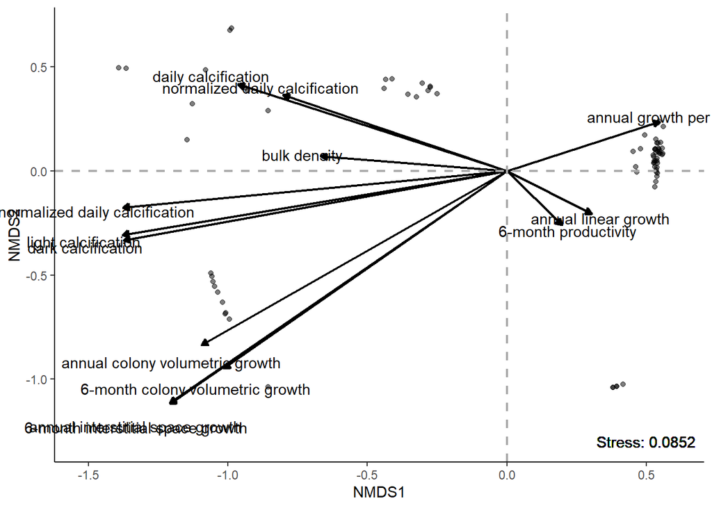

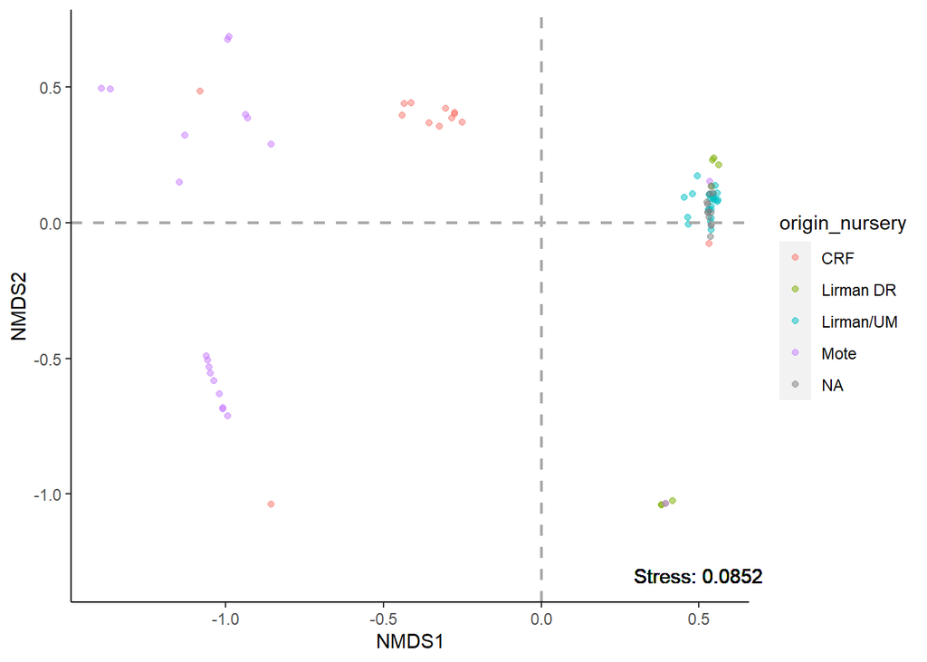

# Appendix

Table A1: Complete list of genotypes

| genotype | origin nursery | traits | datasets | fragments |
| --- | --- | --- | --- | --- |
| 1 | Mote | 13 | 5 | 284 |
| 41 | Mote | 13 | 4 | 173 |
| 7 | Mote | 13 | 4 | 246 |
| 31 | Mote | 13 | 3 | 192 |
| 44 | Mote | 13 | 3 | 190 |
| 13 | Mote | 12 | 3 | 168 |
| 3 | Mote | 12 | 2 | 198 |
| 50 | Mote | 12 | 2 | 214 |
| 62 | Mote | 12 | 2 | 162 |
| 36 | CRF | 7 | 1 | 121 |
| 34 | Mote | 6 | 2 | 102 |
| K2 | CRF | 6 | 2 | 59 |
| K3 | CRF | 6 | 2 | 56 |
| U41 | CRF | 6 | 2 | 54 |
| U44 | CRF | 6 | 2 | 45 |
| U77 | CRF | 6 | 2 | 48 |
| 5 | Mote | 5 | 3 | 135 |
| 54 | Mote | 5 | 3 | 156 |
| 56 | Mote | 5 | 3 | 123 |
| K1 | CRF | 5 | 2 | 60 |
| 47 | Mote | 5 | 1 | 100 |
| 63 | Mote | 5 | 1 | 93 |
| K25 | CRF | 5 | 1 | 38 |
| U47 | CRF | 5 | 1 | 53 |
| U73 | CRF | 5 | 1 | 53 |
| U78 | CRF | 5 | 1 | 52 |
| Cooper’s | Lirman/UM | 4 | 4 | 265 |
| Grounding | Lirman/UM | 4 | 3 | 128 |
| Steph’s | Lirman/UM | 4 | 3 | 143 |
| Struggle Bus | Lirman/UM | 4 | 3 | 111 |

[output cut: 97 more lines]

Table A2: Complete list of genotypes for all traits

| trait | unit | method | genotype | origin nursery | mean | sd | min | max | n | datasets |
| --- | --- | --- | --- | --- | --- | --- | --- | --- | --- | --- |
| 6-month colony volumetric growth | proportionate growth | 3D photogrammetry |  |  | 1.82 | 1.1 | 0.0379 | 6.21 | 249 | 2 |
|  |  |  | BC-g | Lirman/UM | 2.53 | 1.4 | 1.01 | 5.03 | 13 | 1 |
|  |  |  | Stagreef | Lirman/UM | 2.5 | 1.22 | 0.953 | 5.56 | 32 | 1 |
|  |  |  | 41 | Mote | 2.32 | 1.08 | 0.761 | 4.56 | 10 | 1 |
|  |  |  | Sunny Isles-F | Lirman/UM | 2.03 | 1.01 | 0.654 | 5.23 | 27 | 1 |
|  |  |  | 7 | Mote | 1.88 | 0.795 | 0.833 | 3.26 | 13 | 1 |
|  |  |  | MK-9 | Lirman/UM | 1.8 | 0.622 | 0.517 | 2.99 | 23 | 1 |
|  |  |  | 62 | Mote | 1.73 | 0.992 | 0.555 | 3.5 | 10 | 1 |
|  |  |  | 36 | CRF | 1.71 | 1.08 | 0.244 | 4.89 | 20 | 1 |
|  |  |  | BC-h | Lirman/UM | 1.58 | 0.764 | 0.603 | 3.72 | 13 | 1 |
|  |  |  | 50 | Mote | 1.56 | 1.45 | 0.0379 | 6.21 | 19 | 1 |
|  |  |  | 31 | Mote | 1.54 | 1.06 | 0.166 | 3.95 | 14 | 1 |
|  |  |  | 3 | Mote | 1.51 | 1.09 | 0.229 | 3.94 | 16 | 1 |
|  |  |  | 44 | Mote | 1.31 | 0.875 | 0.0661 | 2.65 | 13 | 1 |
|  |  |  | 1 | Mote | 1.31 | 0.926 | 0.128 | 2.96 | 15 | 1 |
|  |  |  | 13 | Mote | 1.13 | 0.816 | 0.0942 | 2.43 | 11 | 1 |
| 6-month interstitial space growth | proportionate growth | 3D photogrammetry |  |  | 6.27 | 5.57 | -1.82 | 35.8 | 136 | 1 |
|  |  |  | 36 | CRF | 7.97 | 5.32 | 1.6 | 22.7 | 19 | 1 |
|  |  |  | 62 | Mote | 7.54 | 5.35 | 0.968 | 15.3 | 10 | 1 |
|  |  |  | 7 | Mote | 6.95 | 4.75 | 0.669 | 19.5 | 14 | 1 |
|  |  |  | 50 | Mote | 6.7 | 8.54 | 0.432 | 35.8 | 17 | 1 |
|  |  |  | 31 | Mote | 6.43 | 6.27 | 0.287 | 19.5 | 15 | 1 |
|  |  |  | 41 | Mote | 6.35 | 4.53 | 1.36 | 16.8 | 10 | 1 |
|  |  |  | 13 | Mote | 5.89 | 5.2 | -1.82 | 14.3 | 10 | 1 |
|  |  |  | 3 | Mote | 5.79 | 5.9 | 0.0887 | 19.8 | 15 | 1 |
|  |  |  | 44 | Mote | 4.38 | 4.05 | 0.0694 | 12.2 | 13 | 1 |
|  |  |  | 1 | Mote | 3.99 | 2.97 | 0.151 | 10.1 | 13 | 1 |
| 6-month productivity | proportionate growth | ruler |  |  | 1.66 | 1.34 | 0 | 17 | 2330 | 10 |
|  |  |  | Anas’-GO | Lirman/UM | 4.61 | 1.96 | 2.55 | 6.45 | 3 | 1 |
|  |  |  | Sunny Isles-A | Lirman/UM | 4.51 | 1.98 | 1.5 | 7.05 | 5 | 1 |

[output cut: 412 more lines]